# Final project

Lily Nguyen

# Introduction

Underage drinking continues to be a widespread problem, resulting in approximately 5,000 deaths among young people every year. This issue is closely tied to the significant physical, emotional, and lifestyle changes that occur during the transition from adolescence to young adulthood. Adolescents undergo puberty and seek greater independence, making them more susceptible to risky drinking behaviors.

The decision to start or continue drinking is a complex interplay between genetic factors and the environment. Some individuals may have a genetic predisposition to alcohol consumption, while external influences such as family dynamics, peer pressure, and societal norms also play a role. Understanding underage drinking requires considering the developmental aspects of adolescence and the multiple factors influencing behavior.

Preventing underage drinking requires a comprehensive approach. Education is vital in providing young people with knowledge about the risks and consequences of alcohol consumption. Prevention programs should focus on promoting healthy coping mechanisms, enhancing decision-making skills, and raising awareness of the dangers of underage drinking. Additionally, policy interventions are necessary to restrict access to alcohol, including enforcing underage drinking laws and implementing stricter regulations on sales.

By addressing underage drinking through a comprehensive lens that considers developmental factors, education, prevention programs, and policy interventions, we can work towards reducing its prevalence and mitigating its harmful effects on young individuals.

# Ethical consideration

Ethically, it is crucial to ensure that the study design and the hypothesis being tested using the collected data are appropriate and aligned with ethical standards. In this case, the data collected by Professor Paulo Cortez from the University of Minho, Portugal, is related to student achievement in secondary education from two Portuguese schools (https://www.kaggle.com/datasets/uciml/student-alcohol-consumption). The data includes student grades, demographic, social, and school-related features, and was collected using school reports and questionnaires.

One important ethical consideration is obtaining informed consent from the students whose data is being collected. It is crucial that the students were adequately informed about the purpose of the data collection, how their information would be used, and any potential risks or benefits associated with participating in the study. Ensuring voluntary participation and protecting the privacy and confidentiality of the students’ personal information is essential.

Furthermore, before conducting the research, a comprehensive assessment of potential risks and benefits should have been conducted. This involves weighing the benefits of the study, such as the potential insights gained from analyzing the data, against any potential risks, such as the potential identification of individuals or the misuse of the data. Safeguarding the privacy and anonymity of the participants is essential, and steps should have been taken to ensure that the data is securely stored and handled in accordance with relevant data protection regulations.

Overall, ethical considerations in this context involve obtaining informed consent, protecting participant privacy, and conducting a thorough risk-benefit analysis to ensure that the study design and use of the collected data are conducted ethically and responsibly.

# Data Explanation and Exploration

First of all, let’s download some packages and the dataset. We are going to call the data “students”.

```r
library(ggplot2)
library(ggthemes)
library(tidyverse)
library(tidymodels)
library(GGally)
library(ggfortify)
students <- read.csv("student-mat.csv")
```

The whole dataset consists of thirty-three variables, but in this project, we will be focusing on the variables presenting the relationship between alcohol consumption and the students’ social and educational life.

```r
students_filtered <- subset(students, select = c("G3", "Dalc", "Walc", "failures", "famrel", "romantic", "health", "sex", "age"))
```

Now, let’s look at summaries of the data in a couple different ways. The summary() will shows us the some statistics about each of the individual variables. The str() tells what type of variable each of the columns are. The names() function displays each of the variables in the data set. Glimpse() also tells us what type of variable each of the columns are.

```r
summary(students_filtered)
```

```
##        G3             Dalc            Walc          failures
##  Min.   : 0.00   Min.   :1.000   Min.   :1.000   Min.   :0.0000
##  1st Qu.: 8.00   1st Qu.:1.000   1st Qu.:1.000   1st Qu.:0.0000
##  Median :11.00   Median :1.000   Median :2.000   Median :0.0000
##  Mean   :10.42   Mean   :1.481   Mean   :2.291   Mean   :0.3342
##  3rd Qu.:14.00   3rd Qu.:2.000   3rd Qu.:3.000   3rd Qu.:0.0000
##  Max.   :20.00   Max.   :5.000   Max.   :5.000   Max.   :3.0000
##      famrel        romantic             health          sex
##  Min.   :1.000   Length:395         Min.   :1.000   Length:395
##  1st Qu.:4.000   Class :character   1st Qu.:3.000   Class :character
##  Median :4.000   Mode  :character   Median :4.000   Mode  :character
##  Mean   :3.944                      Mean   :3.554
##  3rd Qu.:5.000                      3rd Qu.:5.000
##  Max.   :5.000                      Max.   :5.000
##       age
##  Min.   :15.0
##  1st Qu.:16.0
##  Median :17.0
##  Mean   :16.7
##  3rd Qu.:18.0
##  Max.   :22.0
```

```r
str(students_filtered)
```

```
## 'data.frame':    395 obs. of  9 variables:
##  $ G3      : int  6 6 10 15 10 15 11 6 19 15 ...
##  $ Dalc    : int  1 1 2 1 1 1 1 1 1 1 ...
##  $ Walc    : int  1 1 3 1 2 2 1 1 1 1 ...
##  $ failures: int  0 0 3 0 0 0 0 0 0 0 ...
##  $ famrel  : int  4 5 4 3 4 5 4 4 4 5 ...
##  $ romantic: chr  "no" "no" "no" "yes" ...
##  $ health  : int  3 3 3 5 5 5 3 1 1 5 ...
##  $ sex     : chr  "F" "F" "F" "F" ...
##  $ age     : int  18 17 15 15 16 16 16 17 15 15 ...
```

```r
names(students_filtered)
```

```
## [1] "G3"       "Dalc"     "Walc"     "failures" "famrel"   "romantic" "health"
## [8] "sex"      "age"
```

```r
glimpse(students_filtered)
```

```
## Rows: 395
## Columns: 9
## $ G3       <int> 6, 6, 10, 15, 10, 15, 11, 6, 19, 15, 9, 12, 14, 11, 16, 14, 1…
## $ Dalc     <int> 1, 1, 2, 1, 1, 1, 1, 1, 1, 1, 1, 1, 1, 1, 1, 1, 1, 1, 2, 1, 1…
## $ Walc     <int> 1, 1, 3, 1, 2, 2, 1, 1, 1, 1, 2, 1, 3, 2, 1, 2, 2, 1, 4, 3, 1…
## $ failures <int> 0, 0, 3, 0, 0, 0, 0, 0, 0, 0, 0, 0, 0, 0, 0, 0, 0, 0, 3, 0, 0…
## $ famrel   <int> 4, 5, 4, 3, 4, 5, 4, 4, 4, 5, 3, 5, 4, 5, 4, 4, 3, 5, 5, 3, 4…
## $ romantic <chr> "no", "no", "no", "yes", "no", "no", "no", "no", "no", "no", …
## $ health   <int> 3, 3, 3, 5, 5, 5, 3, 1, 1, 5, 2, 4, 5, 3, 3, 2, 2, 4, 5, 5, 1…
## $ sex      <chr> "F", "F", "F", "F", "F", "M", "M", "F", "M", "M", "F", "F", "…
## $ age      <int> 18, 17, 15, 15, 16, 16, 16, 17, 15, 15, 15, 15, 15, 15, 15, 1…
```

Before exploring further, let me give a brief explanation about the measurement for these variables. In this dataset, variables are not assessed based on real amount of things, they are calculated and graded on a scale from 1 to 5 (1 means very low, and 5 means very high).

First, we will make a new variable presenting the total amount of alcohol consumed by students both on weekdays and the weekends.

```r
students_filtered <- students_filtered %>%
  mutate(Talc = Dalc + Walc)
```

We are going to look at the distribution of the amount of alcohol students drink. The face_wrap() function helps us see the difference between how much male and female students drink.

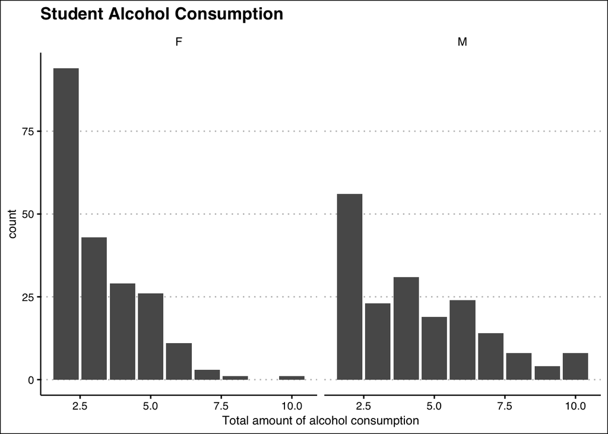

```r
ggplot(students_filtered, aes(x = Talc)) +
  geom_bar() +
  facet_wrap(~sex) +
  labs(title = "Student Alcohol Consumption", x = "Total amount of alcohol consumption") +
  theme_clean()
```

On the other hand, as the amount of alcohol consumption increases (starting from 5.0 on the scale), male students demonstrate a substantial increase in their alcohol intake compared to female students. This indicates that as the quantity of alcohol consumed rises, the difference in drinking patterns between males and females becomes more pronounced, with males consuming significantly more alcohol than females.

# Statistical Analysis and Interpretation

In the next step, we are going to make a scatter plot to look at the relationship between the amount of alcohol students consumed and their quality of family relationships.

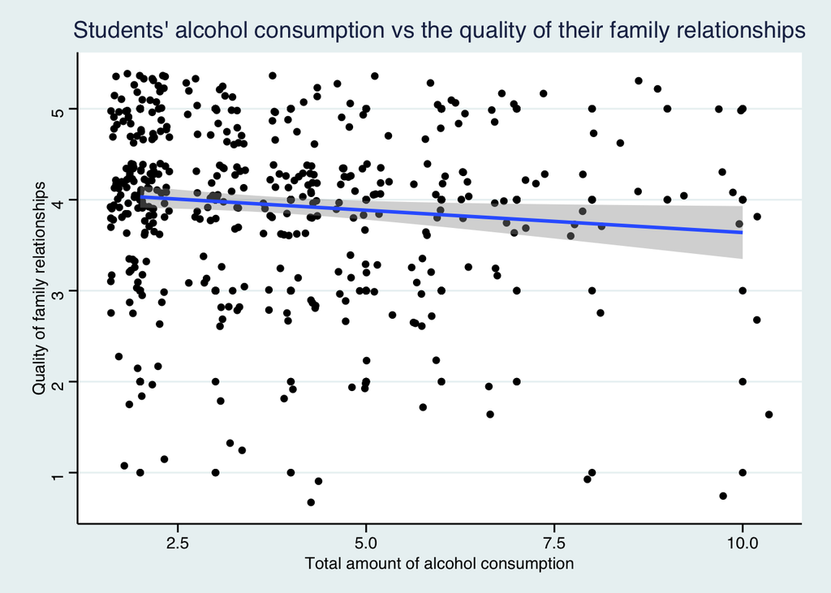

```r
ggplot(students_filtered, aes(Talc, famrel))+
  geom_point()+
  geom_jitter()+
  geom_smooth(method = "lm") +
  labs(title = "Students' alcohol consumption vs the quality of their family relationships", x = "Total amount of alcohol consumption", y = "Quality of family relationships") +
  theme_stata()
```

Now, let’s run a linear regression. With this linear regression, we are going to plot the quality of family relationships by the alcohol consumption.

```r
students_reg1 <- linear_reg() %>%
  set_engine("lm") %>%
  fit(Talc~famrel, data = students_filtered)
summary(students_reg1$fit)
```

```
##
## Call:
## stats::lm(formula = Talc ~ famrel, data = data)
##
## Residuals:
##     Min      1Q  Median      3Q     Max
## -2.4787 -1.7588 -0.5188  1.2412  6.4812
##
## Coefficients:
##             Estimate Std. Error t value Pr(>|t|)
## (Intercept)   4.7186     0.4489  10.512   <2e-16 ***
## famrel       -0.2400     0.1110  -2.162   0.0312 *
## ---
## Signif. codes:  0 '***' 0.001 '**' 0.01 '*' 0.05 '.' 0.1 ' ' 1
##
## Residual standard error: 1.975 on 393 degrees of freedom
## Multiple R-squared:  0.01176,    Adjusted R-squared:  0.009242
## F-statistic: 4.675 on 1 and 393 DF,  p-value: 0.0312
```

Furthermore, the analysis indicates that as the quality of family relationships improves, there is a corresponding decrease in the amount of alcohol consumed. This finding suggests a potential inverse relationship between family relationship quality and alcohol consumption among students.

Consequently, based on the results of this analysis, it can be concluded that there is not a substantial correlation between the amount of alcohol consumed by students and their relationships with their families. The influence of family relationships on alcohol consumption among students may be relatively minor, with other factors potentially playing more significant roles in determining drinking behaviors.

To check whether or not our predictor variables are correlated with one another, we are going to run a multicollinearity test using the ggpairs() functions.

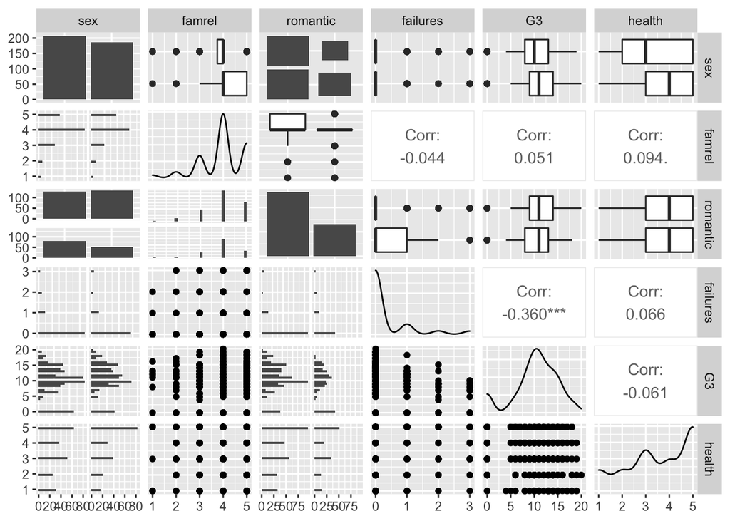

```r
ggpairs(students_filtered, columns = c("sex","famrel","romantic","failures","G3","health"))
```

From this test, we can see that the number of past class failures correlated to the final grade with a correlation score of -0.360. Other than that, the other variables do not seem to be strongly correlated to one another.

For further analysis, I have chosen the variables failures, G3, and health. By removing other variables, I am hoping the regression and models will make more sense without them.

Let’s run a multiple linear regression, which will test whether or not the amount of alcohol is correlated with any of our predictor variables. This process will look rather similar to the process used for the linear regression, just with more variables added in.

```r
students_reg2 <- linear_reg() %>%
  set_engine("lm") %>%
  fit(Talc~failures+G3+health, data=students_filtered)
summary(students_reg2$fit)
```

```
##
## Call:
## stats::lm(formula = Talc ~ failures + G3 + health, data = data)
##
## Residuals:
##     Min      1Q  Median      3Q     Max
## -2.9979 -1.5734 -0.5733  1.1842  6.4266
##
## Coefficients:
##              Estimate Std. Error t value Pr(>|t|)
## (Intercept) 3.209e+00  3.825e-01   8.389 9.05e-16 ***
## failures    3.941e-01  1.426e-01   2.764  0.00599 **
## G3          8.311e-05  2.314e-02   0.004  0.99714
## health      1.213e-01  7.128e-02   1.701  0.08972 .
## ---
## Signif. codes:  0 '***' 0.001 '**' 0.01 '*' 0.05 '.' 0.1 ' ' 1
##
## Residual standard error: 1.961 on 391 degrees of freedom
## Multiple R-squared:  0.03066,    Adjusted R-squared:  0.02322
## F-statistic: 4.122 on 3 and 391 DF,  p-value: 0.006761
```

However, it is important to acknowledge that there are likely other factors at play that influence the amount of alcohol consumed by students. These factors, not accounted for in our analysis, may have a significant impact on alcohol consumption patterns.

When considering the statistical significance of the predictor variables, we find that only the “failures” variable exhibits a p-value of less than 0.05, indicating that it is statistically significant. This suggests that the number of academic failures experienced by students is a significant predictor of alcohol consumption. On the other hand, the other two predictor variables do not demonstrate statistical significance as their p-values exceed 0.05. This suggests that these variables may not have a significant impact on alcohol consumption among students, at least within the context of this analysis.

```r
students_reg3 <- linear_reg() %>%
  set_engine("lm") %>%
  fit(Talc~failures, data=students_filtered)
summary(students_reg3$fit)
```

```
##
## Call:
## stats::lm(formula = Talc ~ failures, data = data)
##
## Residuals:
##     Min      1Q  Median      3Q     Max
## -2.8620 -1.6355 -0.6355  1.3645  6.3645
##
## Coefficients:
##             Estimate Std. Error t value Pr(>|t|)
## (Intercept)   3.6355     0.1083  33.559  < 2e-16 ***
## failures      0.4088     0.1330   3.073  0.00226 **
## ---
## Signif. codes:  0 '***' 0.001 '**' 0.01 '*' 0.05 '.' 0.1 ' ' 1
##
## Residual standard error: 1.963 on 393 degrees of freedom
## Multiple R-squared:  0.02347,    Adjusted R-squared:  0.02099
## F-statistic: 9.446 on 1 and 393 DF,  p-value: 0.002264
```

Now, let’s run an autoplot(). This will help us to validate our linear regression from above.

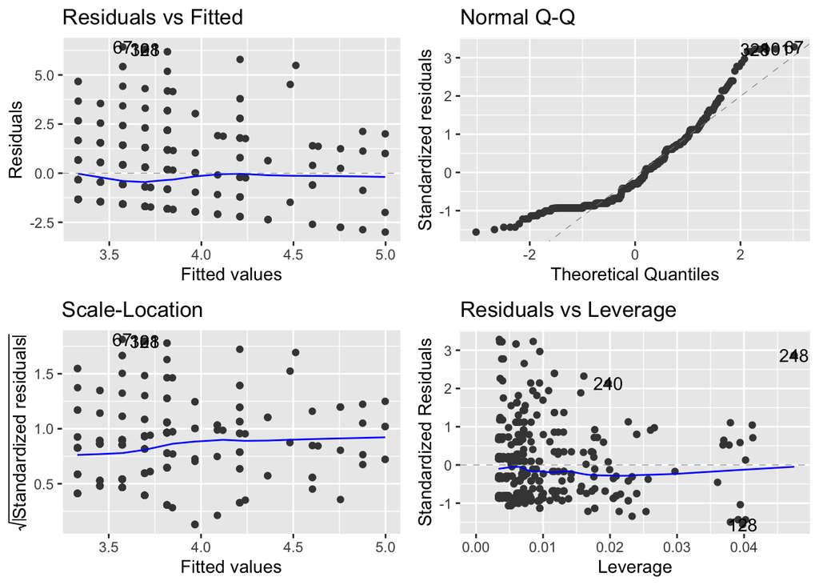

```r
autoplot(students_reg2$fit)
```

Next, we are going to produce a visualization of the relationship between the students’ final grade and the amount of alcohol they consumed on workdays. We would predict that the higher their amount of consumed alcohol the lower their grades.

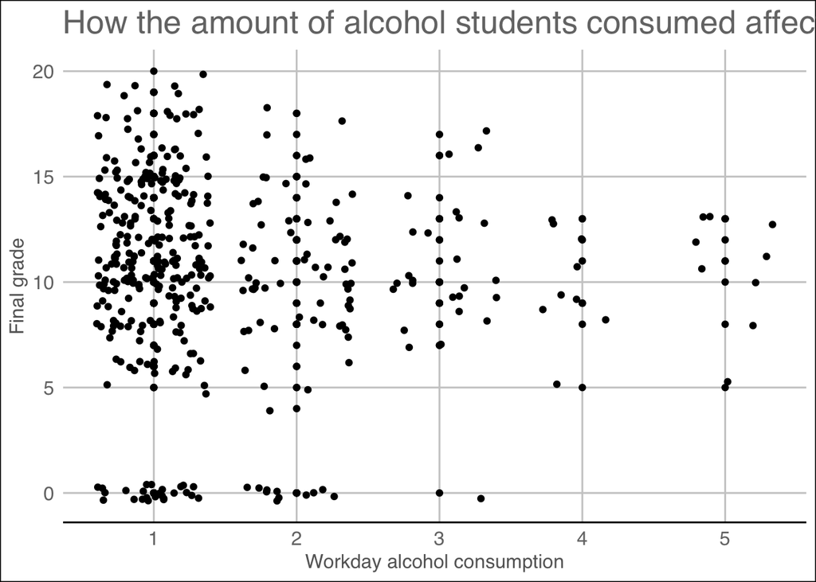

```r
ggplot(students_filtered, aes(x = Dalc, y = G3)) +
  geom_point() +
  geom_jitter() +
  labs(title = "How the amount of alcohol students consumed affects their final grades", x = "Workday alcohol consumption", y = "Final grade") +
  theme_gdocs()
```

Finally, we are going to make a plot to see if the fact that students are in a romantic relationship affects the amount of alcohol they consumed.

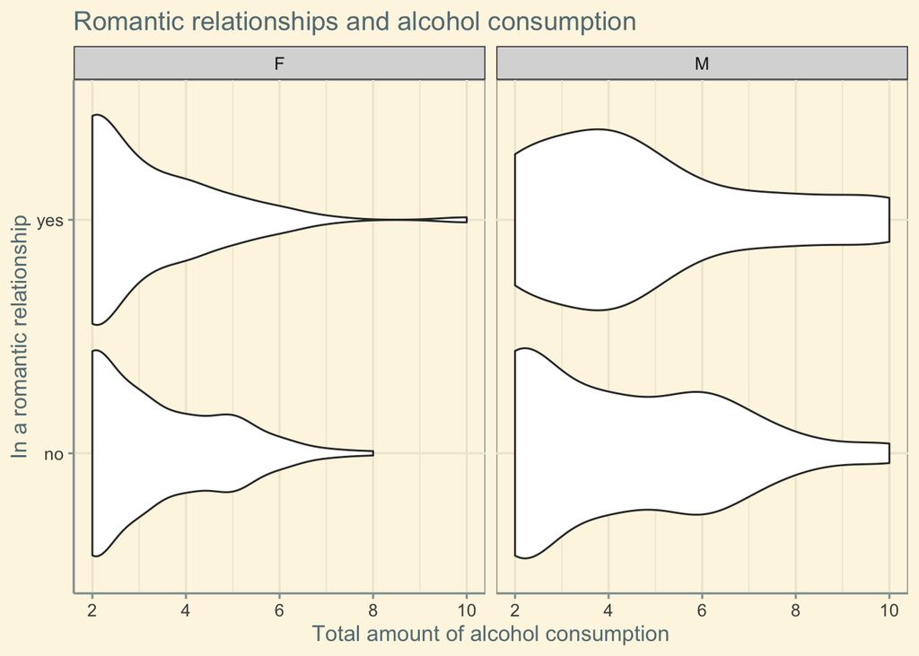

```r
ggplot(students_filtered, aes(x = Talc, y = romantic)) +
  geom_violin() +
  facet_wrap(~sex) +
  labs(title = "Romantic relationships and alcohol consumption", x = "Total amount of alcohol consumption", y = "In a romantic relationship") +
  theme_solarized()
```

Several researches have also pointed out the effect of being in a committed relationship on the alcohol consumption. For the most part, being involved in an intimate relationship appears to have a protective impact, preventing people from engaging in risky habits like smoking, drinking extensively, or engaging in unlawful or high-risk activities.

# Conclusion

In conclusion, we can see clearly that male students normally drink more than females. Based on my analysis so far, what affects the students’ alcohol consumption the most is the number of past class failures. Personally, I would expect this to be the case because the worse they perform in class the more they drink, which leads to even worse performance in class, and then it becomes a cycle. Unfortunately, the R-squared values shows us that the chosen predictor values are not as strong as hypothesized, however we are still able to take away what a small portion of the amount of alcohol consumption is accounted for by.

# Work cited

1. P. Cortez and A. Silva. Using Data Mining to Predict Secondary School Student Performance. In A. Brito and J. Teixeira Eds., Proceedings of 5th FUture BUsiness TEChnology Conference (FUBUTEC 2008) pp. 5-12, Porto, Portugal, April, 2008, EUROSIS, ISBN 978-9077381-39-7. http://www3.dsi.uminho.pt/pcortez/student.pdf
2. “Underage Drinking: Why Do Adolescents Drink, What Are the Risks, and How Can Underage Drinking Be Prevented?”. National Institute on Alcohol Abuse and Alcoholism, January 2006, https://pubs.niaaa.nih.gov/publications/AA67/AA67.htm.
3. “Drinking and Dating: Examining the Link between Relationship Satisfaction, Hazardous Drinking, and Readiness-to-Change in College Dating Relationships”. National Library of Medicine, Jan 1, 2017, https://www.ncbi.nlm.nih.gov/pmc/articles/PMC4795906/